# TE2021

Problema 3

Mauro Esteban Lioy

## # Problema3.2

Para cada uno de los 10 dígitos (0,…,9) se tienen 200 imágenes digitalizadas del dígito escrito a mano. De cada imagen se obtuvieron 649 características (“features”). Se trata de predecir el digito correspondiente a una imagen, en función de sus características. Los datos están repartidos en 6 archivos, todos con m=2000, cada uno de los cuales corresponde a un tipo de características: mfeat-fou, -fac, -kar, -px-, zer-. mor. De modo que luego hay que “pegarlos”. Las primeras 200 filas de cada archivo corresponden a la clase “0”, las siguientes 200 a “1”. etc. Aplique los métodos que le parezcan convenientes y compare sus performances. Los datos están en http://archive.ics.uci.edu/ml/datasets/Multiple+Features

```
1. mfeat-fou: 76 Fourier coefficients of the character shapes;
2. mfeat-fac: 216 profile correlations;
3. mfeat-kar: 64 Karhunen-Love coefficients;
4. mfeat-pix: 240 pixel averages in 2 x 3 windows;
5. mfeat-zer: 47 Zernike moments;
6. mfeat-mor: 6 morphological features.
```

## DATOS

```r
fou<-read.table("mfeat-fou",header=FALSE)
fac<-read.table("mfeat-fac",header=FALSE)
kar<-read.table("mfeat-kar",header=FALSE)
pix<-read.table("mfeat-pix",header=FALSE)
zer<-read.table("mfeat-zer",header=FALSE)
mor<-read.table("mfeat-mor",header=FALSE)

#mor$V1<-as.factor(mor$V1)
#mor$V2<-as.factor(mor$V2)
#mor$V3<-as.factor(mor$V3)


mfeat<-cbind(fou,kar,pix,zer,mor,fac)
colnames(mfeat)<-as.vector(seq(1,649,1))#as.vector(seq(1,649,1))
class<-rep(0,2000)
class[(1:200)]<-0
class[(201:400)]<-1
class[(401:600)]<-2
class[(601:800)]<-3
class[(801:1000)]<-4
class[(1001:1200)]<-5
class[(1201:1400)]<-6
class[(1401:1600)]<-7
class[(1601:1800)]<-8
class[(1801:2000)]<-9
class<-as.factor(class)
datos<-cbind(mfeat,class)
```

## ## DESCRIPTIVO DE LOS DATOS

```r
str(mor)
```

## TRAIN-TEST

```r
set.seed(100)
n = nrow(datos)
trainIndex = sample(1:n, size = round(0.7*n), replace=FALSE)
ds.train = datos[trainIndex ,]
ds.test = datos[-trainIndex ,]
ds.train.x = subset(ds.train, select=c(-class))
ds.test.x = subset(ds.test, select=c(-class))
```

```r
table(ds.train$class)
```

```
  0   1   2   3   4   5   6   7   8   9
129 147 144 136 146 143 148 134 132 141
```

```r
table(ds.test$class)
```

```
 0  1  2  3  4  5  6  7  8  9
71 53 56 64 54 57 52 66 68 59
```

## ——————————————————————————–

## LDA

```r
library(MVN)
```

### Outliers y Contraste de Normalidad

```r
XX<-model.matrix(lm(class~.,data=ds.train))
Xtest<-model.matrix(lm(class~.,data=ds.test))
```

```r
outliers <- mvn(data = fou, mvnTest = "hz", multivariateOutlierMethod = "quan")
```

```
No esto estoy pudiendo computar los outliers con todas las variables. No está claro si tiene sentido mirarlo así.

Lo mismo con los test de contraste por nomalidad multivariado, rompen cuando sumo variables. Pareciera queno puede calcular la inversa.
```

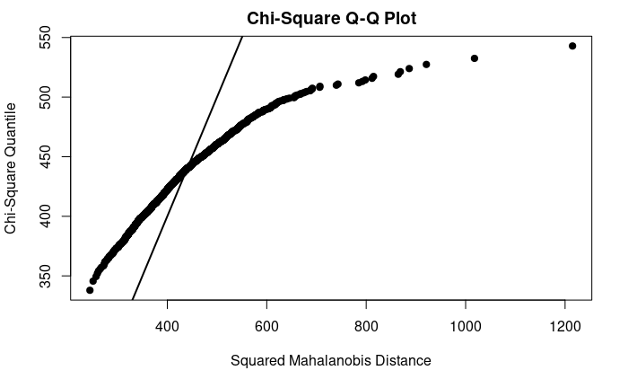

```r
royston_test <- mvn(data = mfeat, mvnTest = "royston", multivariatePlot = "qq")
```

```r
royston_test$multivariateNormality
```

| Test | H | p value | MVN |
| --- | --- | --- | --- |
| Royston | 39090.73 | 0 | NO |

```r
hz_test <- mvn(data = subset(ds.train, select=c(1:132,135:230,231:242,245:260,500:600)), mvnTest = "hz")
hz_test$multivariateNormality
```

```
Veamos la normalidad por variable. Ya es obvio que no va a ser normalmultivariado. Si no es normal por variable, no puede ser normal multivairado.
```

```r
# Contraste de normalidad Shapiro-Wilk para cada variable en cada especie
library(reshape2)
library(knitr)
library(dplyr)
```

```r
ds.train.x =  subset(ds.train, select=c(-class))
datos_tidy <- melt( subset(ds.train, select=c(-399,-416,-469,-477,-492,-484,-491,-502,-506,-521,-522,-585,-586,-507,-508) ), value.name = "valor")
kable(datos_tidy %>% group_by(class, variable) %>% summarise(p_value_Shapiro.test = shapiro.test(valor)$p.value))
```

```r
ds.shapiro = datos_tidy %>% group_by(class, variable) %>% summarise(p_value_Shapiro.test = shapiro.test(valor)$p.value)
```

```r
p1 <- ggplot(data = ds.shapiro, aes(x = p_value_Shapiro.test , fill = class)) +
      geom_histogram(position = "identity", alpha = 0.5, bins = 100)
```

```r
ggarrange(p1, nrow = 1, common.legend = TRUE)
```

```r
 ggplot(data = subset(datos_tidy, variable==33), aes(x = valor, fill = class)) +
      geom_histogram(position = "identity", alpha = 0.5, bins = 20)
```

```r
# Representación de cuantiles normales de cada variable para cada especie
for (i in 0:9) {
    x <- subset(datos_tidy, variable==357 & class == i)$valor
    qqnorm(x, main = paste("class", i), pch = 19, col = i + 1)
    qqline(x)
  }
```

### covarianza

```r
# devtools::install_github("arsilva87/biotools")
library(biotools)
```

```r
boxM(data = mfeat, grouping =datos$class)
```

```
there are one or more levels with less observations than variables!
```

```
    Box's M-test for Homogeneity of Covariance Matrices

data:  mfeat
Chi-Sq (approx.) = Inf, df = 845649, p-value < 2.2e-16
```